# NYC Taxi Trip Duration Prediction

### Observations:

Let's check if there is some relation to the other metrics for these trips?

```python
data[data.store_and_fwd_flag == 1]
```

|  | vendorid | pickup_date | dropoff_date | passenger_count | trip_distance | pickup_longitude | pickup_latitude | ratecodeid | store_and_fwd_flag | dropoff_longitude | ... | pickup_hour_23 | passenger_count_1.0 | passenger_count_2.0 | passenger_count_3.0 | passenger_count_4.0 | passenger_count_5.0 | passenger_count_6.0 | passenger_count_7.0 | passenger_count_8.0 | passenger_count_9.0 |
| --- | --- | --- | --- | --- | --- | --- | --- | --- | --- | --- | --- | --- | --- | --- | --- | --- | --- | --- | --- | --- | --- |

0 rows × 66 columns

### Observations:

So all in all there doesn't seems to be any relation with either of the metric for the offline trips. Let's move ahead

## Total trips Per Hour

Let's take a look at the distribution of the pickups across the 24 hour time scale.

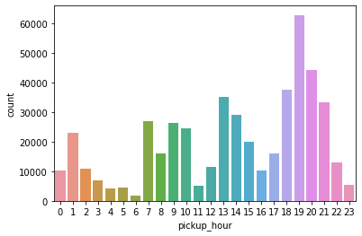

```python
sns.countplot(data.pickup_hour)
plt.show()
```

### Observation

- It's inline with the general trend of taxi pickups which starts increasing from 6AM in the morning and then declines from late evening i.e. around 8 PM. There is no unusual behavior here.

## Total trips per weekday

Let's take a look now at the distribution of taxi pickups across the week.

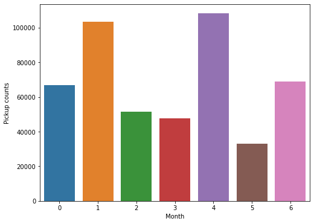

```python
plt.figure(figsize = (8,6))
sns.countplot(data.weekday_num)
plt.xlabel(' Month ')
plt.ylabel('Pickup counts')
plt.show()
```

### Observation

Let's drill down more to see the hourwise pickup pattern across the week

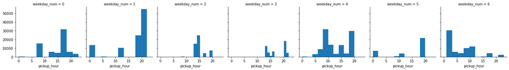

```python
n = sns.FacetGrid(data, col='weekday_num')
n.map(plt.hist, 'pickup_hour')
plt.show()
```

## Total trips per month

Let's take a look at the trip distribution across the months to understand if there is any diffrence in the taxi pickups in different months

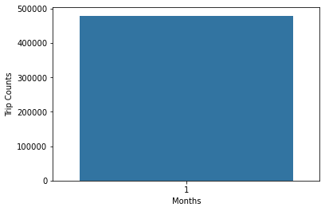

```python
sns.countplot(data.month)
plt.ylabel('Trip Counts')
plt.xlabel('Months')
plt.show()
```

# Bivariate Analysis

Bivariate analysis is used to find out if there is a relationship between two sets of values. It usually involves the variables X and Y.

[figure not shown]

## Trip Duration per hour

- Lets take a look.

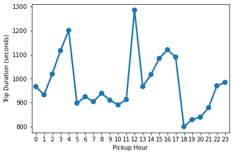

```python
group1 = data.groupby('pickup_hour').trip_duration.mean()
sns.pointplot(group1.index, group1.values)
plt.ylabel('Trip Duration (seconds)')
plt.xlabel('Pickup Hour')
plt.show()
```

## Trip duration per weekday

Let's now analyze the pattern of trip duration during the week.

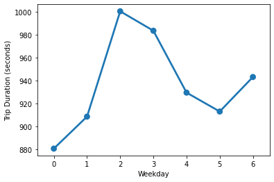

```python
group2 = data.groupby('weekday_num').trip_duration.mean()
sns.pointplot(group2.index, group2.values)
plt.ylabel('Trip Duration (seconds)')
plt.xlabel('Weekday')
plt.show()
```

## Trip duration per month

Let's take a look at the trip duration pattern with respect to the different months.

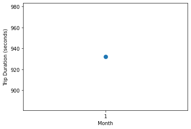

```python
group3 = data.groupby('month').trip_duration.mean()
sns.pointplot(group3.index, group3.values)
plt.ylabel('Trip Duration (seconds)')
plt.xlabel('Month')
plt.show()
```

## Trip duration per vendor

We can also look at the average difference between the trip duration for each vendor. However we do know that vendor 2 has larger share of the market. Let's visualize.

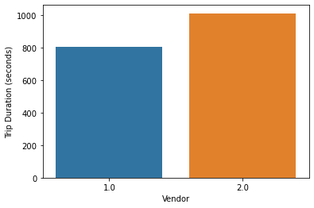

```python
group4 = data.groupby('vendorid').trip_duration.mean()
sns.barplot(group4.index, group4.values)
plt.ylabel('Trip Duration (seconds)')
plt.xlabel('Vendor')
plt.show()
```

Vendor 2 takes the crown. Average trip duration for vendor 2 is higher than vendor 1 by approx 200 seconds i.e. atleast 3 minutes per trip.